# Decomposition of AML transcriptomes to predict survival

```r
require(Seurat)
require(hsc19)
require(plyr)
require(ggplot2)
require(survival)
require(survminer)
require(ggnewscale)
set.seed(1337)
```

## Data preparation

We used a single-cell RNA-seq dataset of n=183 AML patients, selected to represent most genetically defined (WHO) groups (Barinka et al., bioRxiv 2026, doi:10.64898/2026.08.25.746926). This dataset had been annotated by projection on a healthy reference (Triana et al., Nat. Immunol. 2021), to identify the most similar healthy cell type / differentiation state for each cell. We subsetted to cells corresponding to stem and progenitor cells (i.e. up to the promyelocyte stage, and excluding cells resembling mature monocytes, and other mature myeloid, erythroid and lymphoid cells), and summed raw read counts per patient (not shown)

```r
meta <- readRDS("data_AML/metadata.rds") #contains AML-specific transcriptime derived scores
prog_objc_v1 <- readRDS("data_AML/pseudobulks.rds") #is already a seurat object
outcomes <- readRDS("data_AML/outcomes.rds")

prog_objc_v1$RhapsodyID[prog_objc_v1$RhapsodyID == "1_2_7"] <- "1_2_7_x_2_3_4" #Make IDs consistent
colnames(prog_objc_v1)[colnames(prog_objc_v1) == "1_2_7"] <-  "1_2_7_x_2_3_4"
#compute module scores for gene signatures from Rodriguez-Fraticelli
alejo_human <- lapply(alejo_lists, toupper)
prog_objc_v1 <- AddModuleScore(prog_objc_v1, features = alejo_human, name = "alejo", slot = "data")
alejo_metadata <- data.frame(RhapsodyID = prog_objc_v1$RhapsodyID,
                                 prog_objc_v1@meta.data[, grepl("alejo", colnames(prog_objc_v1@meta.data))])
meta <- merge(meta, alejo_metadata)
meta <- merge(meta, outcomes)

rownames(meta ) <- meta$RhapsodyID
rownames(outcomes) <- outcomes$RhapsodyID

prog_objc_v1 <- subset(prog_objc_v1, cells = rownames(meta))
meta <- meta[colnames(prog_objc_v1),]
```

## Decompose data into GRPs

```r
result <- decompose(s = prog_objc_v1)
```

## Associate GRPs with outcomes

The `associate` function here computes both p-value associations, and runs machine learning to compare the predictve value of these predictors, other predictors, and the whole transcriptome (see also manuscript, methods section). It additionally uses pre-specified models (linear combinations of predictors).

```r
meta$WHO_classification <- as.factor(meta$WHO_25)

models <- c("Age", "ELN22_risk", "WHO_classification",
            "Age+Factor_1", "Age+LSC17_mprog_mean")
names(models) <- c("Age", "ELN22 risk", "WHO classification", "Age+Factor_1","Age+LSC17")

other_predictors <- c("mean_G2M_score_progenitors", "mean_S_score_progenitors",sprintf("alejo%d",1:length(alejo_lists)),"LSC17_mprog_mean","healthy_perc_prog_malig", "Myelocytes_pt_mean_malig_prog")

#overall survival: all patients
grp2output_os <- associate_survival_outcome(result, meta, "OS_status", "OS_days", other.predictors = other_predictors, run.ML = T, replicates = 10, cores = 10, arbitrary.models = models)
saveRDS(grp2output_os, file = "grp2output_os.rds")
# overall survival: patients treated with intensive chemotherapy
intensely_treated <- rownames(meta)[meta$therapy_group == "intensive" & !is.na(meta$best_response_chemo)]
meta$response <- meta$best_response_chemo == "CR"
grp2output_response <- associate_binary_outcome(subset(result, include = intensely_treated), meta[intensely_treated,], "response", other.predictors = other_predictors, run.ML = F)

#relapse: Patients who received allo
with_allo <- rownames(meta)[!is.na(meta$relapse_after_allo_status)]
grp2output_rfs <- associate_survival_outcome(subset(result, include = with_allo), meta[with_allo,], "relapse_after_allo_status", "relapse_after_allo_days", other.predictors = other_predictors, run.ML = F)
```

## Make figures

### Figure 4A

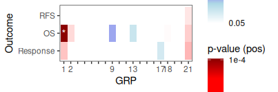

```r
aml <- list(os = grp2output_os, response = grp2output_response, rfs = grp2output_rfs)
pvalues <- lapply(aml, "[[", 1)
pvalues <- lapply(names(pvalues), function(n) {
  x <- pvalues[[n]]
  x$observation <- n
  x <- subset(x, grepl("Factor_", factor_id))
  x$fdr <- p.adjust(x$p_outcome, "fdr")
  x
})
pvalues <- do.call(rbind, pvalues)


pvalues$disease <- "AML"
pvalues$outcome <- factor(with(pvalues, ifelse(observation == "mds", "OS", toupper(observation))), levels = c("RESPONSE", "OS", "RFS", "DA", "VV"))

pvalues$show_value <- with(pvalues, ifelse(p_outcome < 0.05, -log10(p_outcome), -log10(0.05)))
factor_levels <- get_factor_columns(result)
pvalues$factor_id <- factor(pvalues$factor_id, levels = factor_levels)
ylabels <- gsub("Factor_", "", factor_annotation$factor_id); names(ylabels) <- factor_annotation$factor_id
any_sig <- sapply(names(ylabels), function(x) any(pvalues$p_outcome[pvalues$factor_id == x] < 0.05))
ylabels[!any_sig] <- ""
pvalues <- merge(pvalues, factor_annotation)

fig4a <- ggplot(aes(x = factor_id, y = outcome), data = subset(pvalues, (disease == "AML" & outcome %in% c("RESPONSE", "RFS", "OS") ))) +
  geom_blank() +
  geom_tile(aes(fill =show_value), data = subset(pvalues, (disease == "AML" & outcome %in% c("RESPONSE", "RFS", "OS")) & p_outcome < 0.05 & sign_outcome * multiply_with == -1)) +
  scale_fill_gradientn(name = "p-value (neg)", colors = c("white","lightblue","blue", "blue", "darkblue"), breaks = c(-log10(0.05), -log10(0.1 / (19*3)), 4), labels = c("0.05", "Bonferroni", "1e-4"), limits = c(-log10(0.05), max(pvalues$show_value)), na.value = "white") +
  new_scale_fill() +
  geom_tile(aes(fill =show_value),data = subset(pvalues, (disease == "AML" & outcome %in% c("RESPONSE", "RFS", "OS")) & p_outcome < 0.05 & sign_outcome * multiply_with == 1)) +
  scale_fill_gradientn(name = "p-value (pos)", colors = c("white","#FFAAAA","red", "red", "darkred"), breaks = c(-log10(0.05), -log10(0.1 / (19*3)), 4), labels = c("0.05", "Bonferroni", "1e-4"), limits = c(-log10(0.05), max(pvalues$show_value)), na.value = "white") +
  scale_y_discrete(labels = c("RESPONSE" = "Response"), name = "Outcome") +  scale_x_discrete(name = "GRP", labels = ylabels) +
  theme_bw() + theme( panel.grid = element_blank()) + scale_size_area(guide= "none", max_size = 3) +
  geom_text(aes(label = ifelse(p.adjust(p_outcome,"fdr") < 0.1, "*", "")), color = "white",size=4) +
  scale_shape_manual(values = c("1" = 24, "-1" = 25), guide="none")

print(fig4a)
```

### Figure 4B

```
#> `height` was translated to `width`.
```

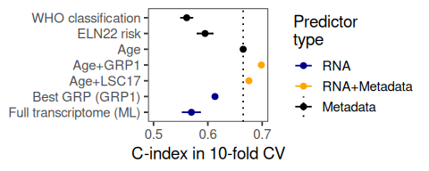

```r
os_cix <- data.frame(what = names(aml$os$c.index),
                     cix = aml$os$c.index,
                     cix.sd = aml$os$c.index.sd)
best_ML <- subset(os_cix, what %in% c("C.cox.de", "C.lasso.de", "C.cox.pcr", "C.lasso.pcr" ))
best_ML <- subset(best_ML, cix == max(cix))
use_model <- best_ML$what
os.cix <- rbind(
  subset(os_cix, !grepl("C\\.[^b]", what)),
  best_ML
)
os.cix$class <- factor(ifelse(os.cix$what %in% c("Age+LSC17", "Age+Factor_1"), "RNA+Metadata",
                       ifelse(os.cix$what %in% c("ELN22 risk", "WHO classification", "Age","Age"), "Metadata",
                              "RNA")), levels = c("RNA", "RNA+Metadata","Metadata"))
os.cix$what <- factor(os.cix$what, levels = rev(c("WHO classification", "ELN22 risk", "Age", "Age+Factor_1","Age+LSC17","C.best.factor","C.best.other",use_model)))
ylab <- c("Best GRP (GRP1)", "Age+GRP1", "Full transcriptome (ML)")
names(ylab) <- c("C.best.factor", "Age+Factor_1", use_model)

fig4b <- ggplot(aes(x = cix, y =what, color = class),data=subset(os.cix, what %in% c("C.best.factor","Age","ELN22 risk","WHO classification", "Age+LSC17","Age+Factor_1", use_model))) + geom_point() +
  geom_errorbarh(aes(xmin= cix-cix.sd, xmax = cix+cix.sd), height=0.1) +
  scale_x_continuous(name = "C-index in 10-fold CV", limits = c(0.5,NA), breaks = seq(0.5,0.7,by=0.1)) +
  geom_vline(aes(xintercept = cix, color = class), data = subset(os.cix, what == "Age"), linetype=3)+
  scale_y_discrete(labels = ylab) +
  scale_color_manual(values = c("Metadata" = "black", "RNA" = "darkblue", "RNA+Metadata" = "orange"),, name = "Predictor\ntype")+
  theme_bw(base_size=14) + theme(panel.grid = element_blank(),axis.title.y = element_blank())

print(fig4b)
```

### Figure 4C

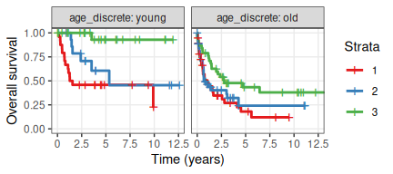

```r
meta$age_discrete <- factor(ifelse(meta$Age <= quantile(meta$Age, 1/3), "young", "old"), levels = c("young", "old"))
meta$f20discrete <- infotheo::discretize(result@result["Factor_1",] * factor_annotation$multiply_with[factor_annotation$factor_id == "Factor_1"], nbins = 3)$X


fit <- survfit(Surv(OS_days/365, OS_status) ~ f20discrete + age_discrete, data = meta)

os_cox <- ggsurvplot_facet(fit, data = meta, facet.by = "age_discrete", ggtheme = theme_minimal(), ylab = "Overall survival",xlab = "Time (years)", palette = "Set1") + theme_bw() + theme(panel.grid.minor =  element_blank())

   print(os_cox)
```

### Figure 4D

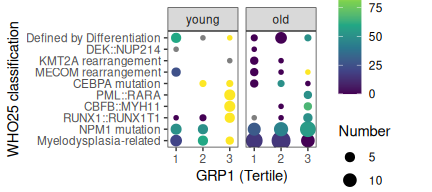

```r
by.who.and.tertile <- ddply(meta, c("age_discrete","WHO_25", "f20discrete"), summarise, n = length(age_discrete), surv = sum(OS_status == 0 & OS_days > 365*3) / sum((OS_status == 1 & OS_days < 365*3)|(OS_status == 0 & OS_days > 365*3)))
by.who.and.age <- ddply(meta, c("age_discrete","WHO_25"), summarise, total= length(age_discrete))
by.who.and.tertile <- merge(by.who.and.tertile, by.who.and.age)
by.who.and.tertile$fraction <- with(by.who.and.tertile, n/total)
genoplot2 <- ggplot(aes(x = f20discrete, y = WHO_25, color = 100*surv, size=n),data = by.who.and.tertile) + geom_point() + facet_wrap(~age_discrete) + theme_bw() + theme(panel.grid = element_blank()) + scale_color_viridis_c(name = "% alive after\n3 years") + scale_size_area(name = "Number") + ylab("WHO25 classification") + scale_x_continuous(breaks =1:3, name = "GRP1 (Tertile)") + coord_cartesian(xlim = c(0.8,3.2))

print(genoplot2)
```